# Simulation Model Notes

*This simulation is the same as ''Marshall_notes_recentered_dists'' but now instead of the marker having a mixture of normals with zero mean, we set the mean as the crossing point of the two risk curves (ie where the trt effect given Y is zero).*

[link to the notes for the previous model](http://mdbrown.github.io/adaproj_simstudy2014_notes.html)

## plot of interest

Recall that:

- the old model: marker distributions are centered at zero
- the new model: marker distributions are centered at \( y_0 \) s.t. \( \Delta(y = y_0) = 0 \). *(See below for more details regarding the simulation model)*

This figure shows \( p_0 = Pr(D=1|T=0) \) and \( p_1 = Pr(D=1|T=1) \) for the new model (red dot) compared to the \( p_0 \) and \( p_1 \) for the old model (black vertical and horizontal lines). We see that shifting the marker mean causes the largest change from old to new when the difference between \( q_0 \) and \( q_1 \) is large. The shift changes the values of \( p_0 \) and \( p_1 \) to be more similar to each other, which defeats the purpose of trying to set the marginals and look at the coverage.

For the figure below \( k = 4 \) and \( p = 0.1 \), but this is largely irrelevant because these plots look very similar for all values of \( k \) and \( p \).

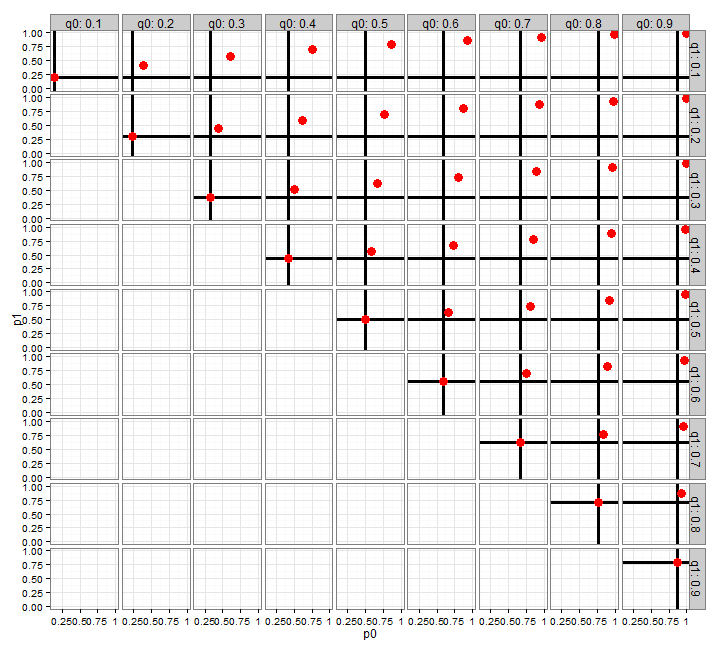

## Modeling assumptions

- Y: mixture of normals with: \( f(y) = p\phi(-\beta_1/\psi_2, c_1) + (1-p)\phi(-\beta_1/\psi_2, c_2) \)
  - \( p\in(0,1) \)
  - \( k = c_2/c_1 \)
  - \( var(Y) = 1 \).
- \( logit(Pr(D = 1 | T,Y)) = \beta_0 + \beta_1T +\psi_1Y + \psi_2YT \)
  - \( \psi_1 = \psi_2=1 \) and \( \beta_0, \beta_1 \) chosen to fix:
  - \( q_0 = expit(\beta_0) \)
  - \( q_1 = expit(\beta_0 + \beta_1) \)

and

- \( p0 = Pr(D=1|T=0) \)
- \( p1 = Pr(D=1|T=1) \)

## Additional plots

1. Risk curves
2. marker distribution
3. the proportion of observations with 'small' treatment effects (ie the proportion of events near the boundary)
4. the distribution of treatment effects
5. the value of theta

## Risk Curves(top)

Risk by F(y) given trt by q0 and q1. True value of Theta in grey.

### \( P = .1 \), \( k = 30 \).

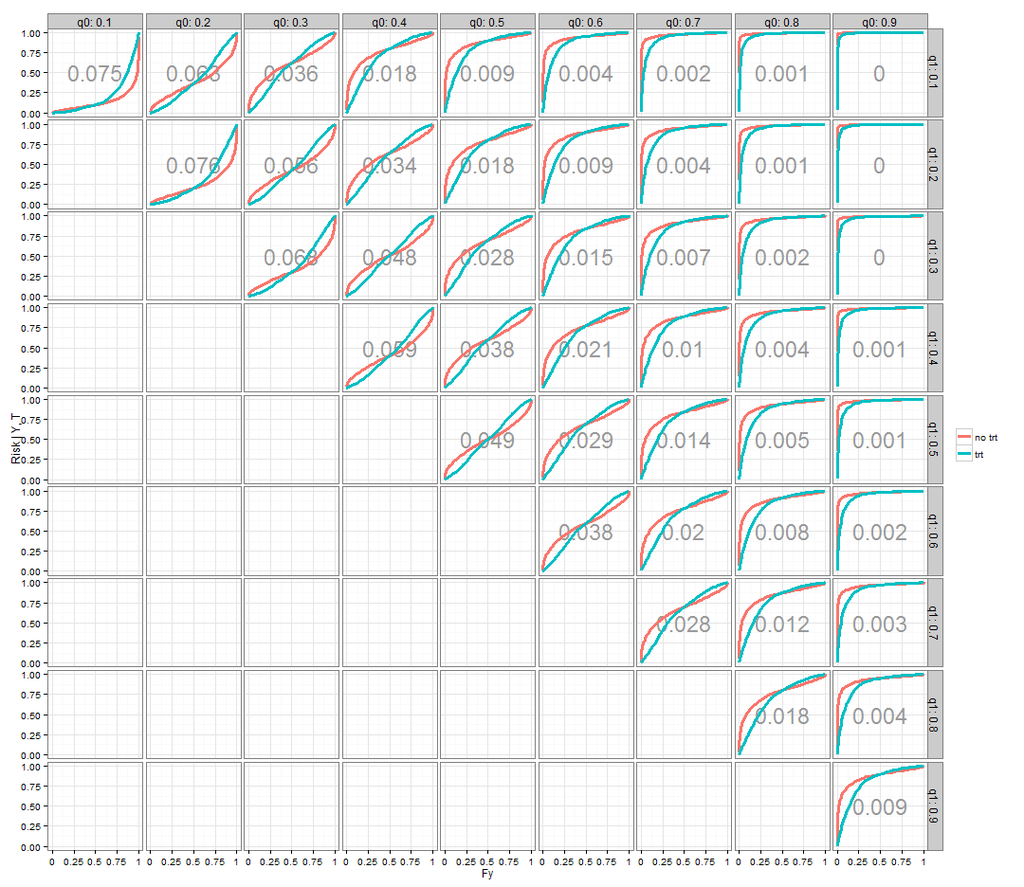

### \( P = .1 \), \( k = 4 \).

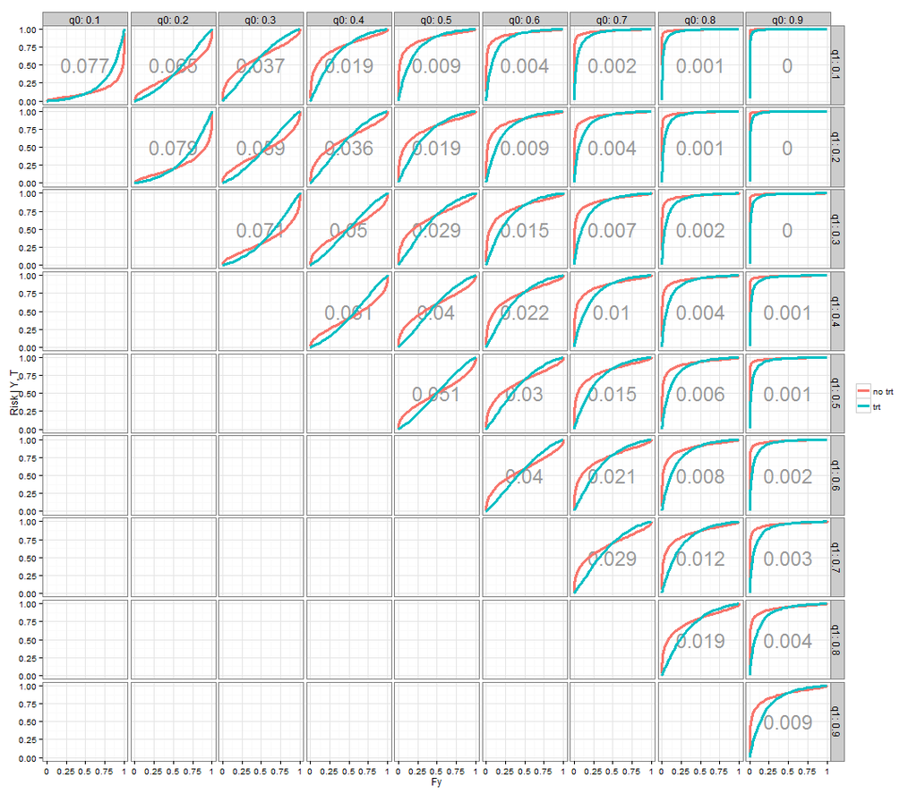

## Treatment Effect Distribution(top)

Distribution of \( \Delta(y) = Pr(D=1|T=0, Y) - Pr(D-1|T=1, Y) \) by \( F(y) \).

### \( K = 30 \)

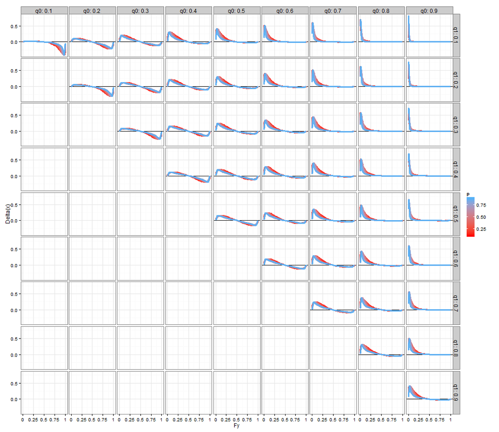

### \( K = 4 \)

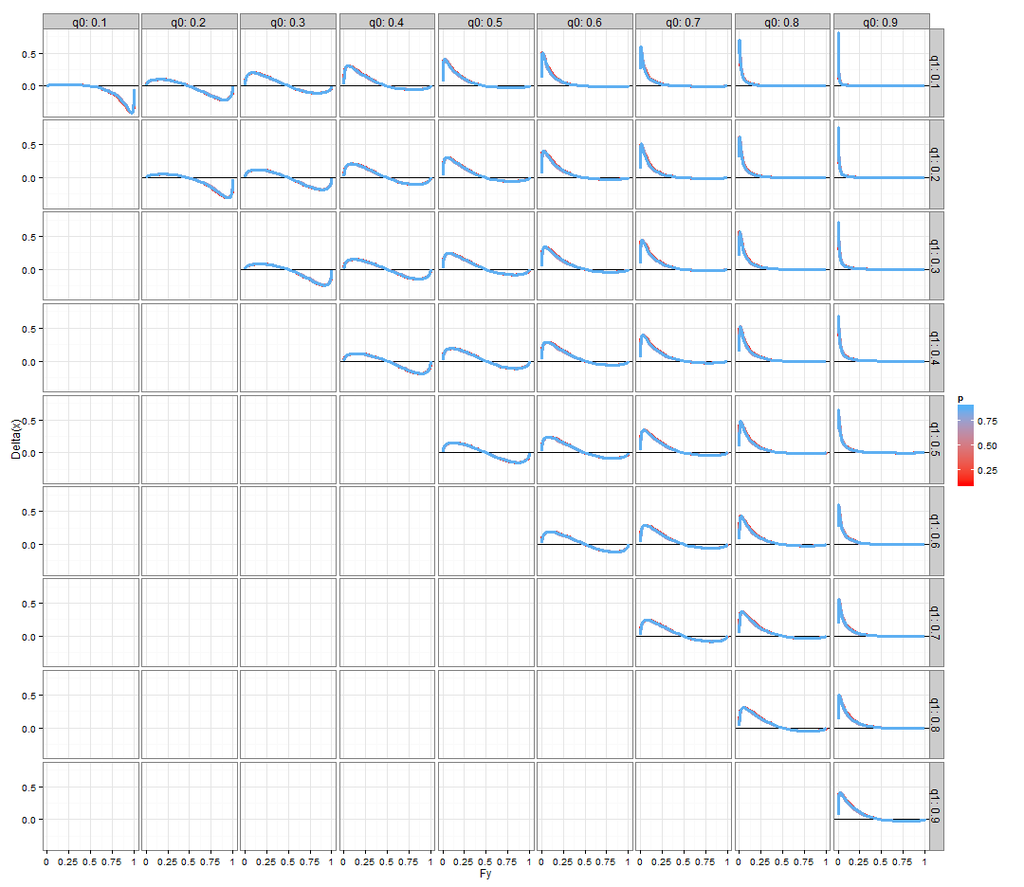

## Theta by p(top)

### K is denoted by color

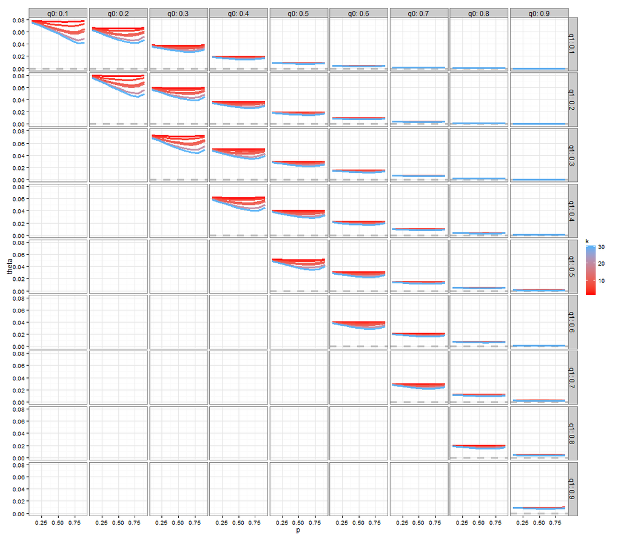

## Marker Distribution(top)

pdf of y colored by p. The vertical black line indicates where \( \Delta(y)=0 \).

### \( K=30 \)

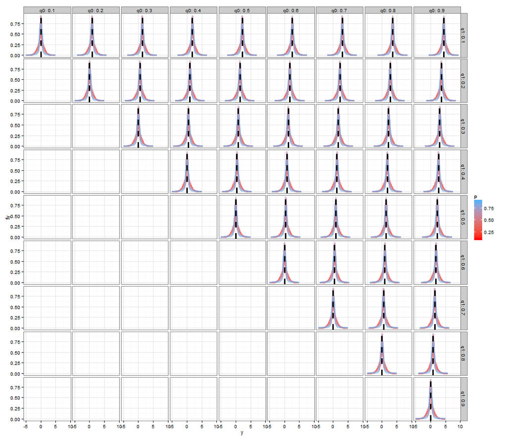

### \( K=4 \)

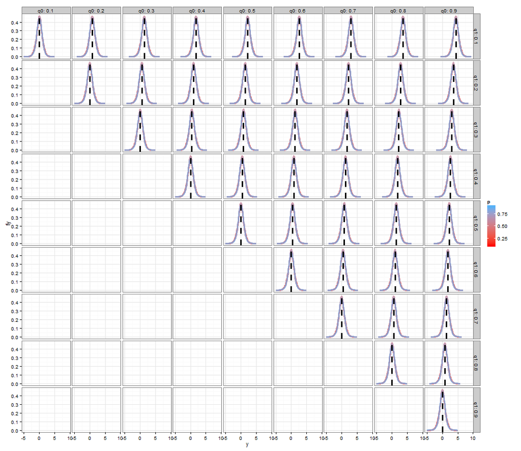

## Proportion of markers near the boundary(top)

This is a plot of p (x-axis) vs \( F(y_{\Delta=0} + 0.01) - F(y_{\Delta=0} - 0.01) \) where \( \Delta(y_{\Delta=0}) = 0 \). This is a very arbitrary measure of proportion of observations near the boundary of interest.

### K is denoted by color.

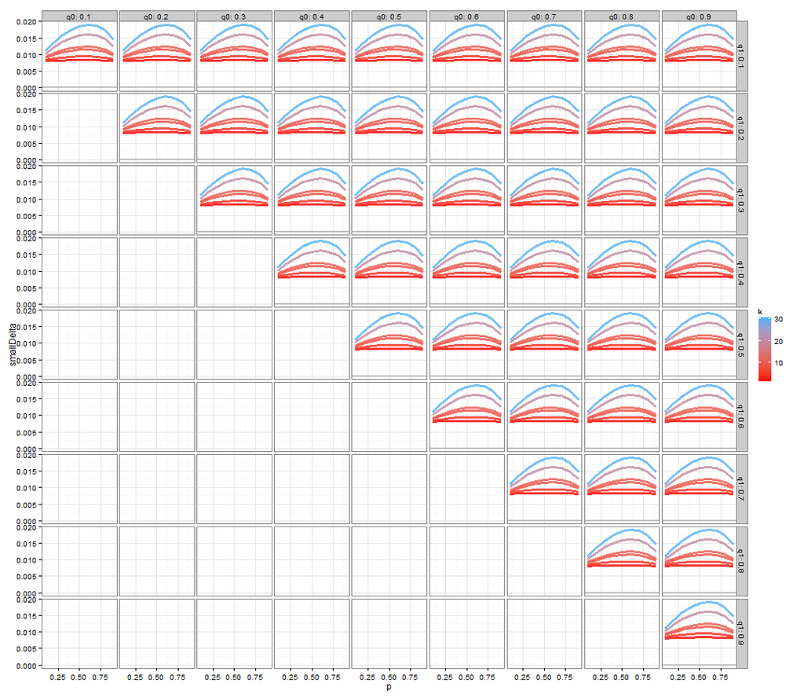